# NadaHelperFile

APB

16/05/2018

### Overview of Data

The data we are using are

1. `compartment_modelling.csv`: thus is a dataframe containing estimates of species richness from iNEXT and habitat data for each compartment.
2. `comp_age.csv`: these are the raw abundance data of each species in each compartment

### Overview of modelling

We are implementing 2 methods of analysis.

The first uses the species richness data estimated as the Asymptotic value from iNEXT. We use `lm(SpeciesRichness ~ Habitat Characteristics)` and mix this with an analysis of effect sizes.

This asks the simple question of whether habitat characteristics influence the species richness.

The second uses the raw abundances of every species for each compartment. The approach here uses a multivariate generalised linear model specifically designed to use at site x species matrix of observations of species abundances. The tools are in the `mvabund` package which has a great introduction via https://www.youtube.com/watch?v=KnPkH6d89l4 and a good blog introduction via http://environmentalcomputing.net/introduction-to-mvabund/.

This asks whether the habitat characteristics influence the species composition of the community.

### library preps

```r
# for plotting
library(GGally)
library(gridExtra)
library(ggrepel)

# for modelling and data wrangling
library(car) # Anova()
library(heplots) # etasq effect size
library(mvabund) # manyglm
library(tidyverse) # lots + ggplot2

library(broom)
library(knitr)
```

### Read in the data

```r
SR_data <- read_csv("./DataSources/compartment_modelling.csv")
comp_age <- read_csv("./DataSources/comp_age.csv")
```

The SR_data is ready for use in the linear modelling framework. For the mvabund method, we need two objects: the matrix of site x species values and the habitat data frame.

```r
# prepare the abundance data
abund_dat <- comp_age %>%
  ungroup() %>%
  select(starts_with("Sp.")) %>%
  mvabund()

# prepare the habitat data
hab_dat <- SR_data %>%
  select(-Site, -order, -coverage, - diversity_estimate) %>%
  as.data.frame()
```

### The iNEXT data and linear Model + effect sizes

First, lets look at species richness (Asymptotic estimates from iNEXT) versus the habitat variables.

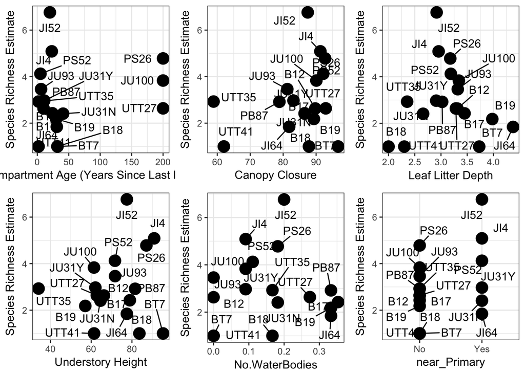

Now, lets build a model. We start by allowing `x` and `x^2` terms and asking whether there is a difference between the polynomial model and a linear model. There is no evidence that adding the second order terms explains additional variation, so we will focus on the linear model (the p-value says that there is no difference between the polynomial and linear model, so we use the simplest model….)

```r
# linear model with all terms; polynomial 2 and 1
mod_full_poly <- lm(diversity_estimate ~ poly(compartment_age,2) +
                 poly(canopy_closure,2) + poly(leaf_litter_depth,2) + poly(understory_height,2) +
                 No_WaterBodies + near_Primary,
                 data = SR_data)

mod_full_lin <- lm(diversity_estimate ~ compartment_age +
                 canopy_closure + leaf_litter_depth + understory_height +
                 No_WaterBodies + near_Primary, data = SR_data)

# step 1 - no difference between models via SS/F
anova(mod_full_poly, mod_full_lin)
```

```
## Analysis of Variance Table
##
## Model 1: diversity_estimate ~ poly(compartment_age, 2) + poly(canopy_closure,
##     2) + poly(leaf_litter_depth, 2) + poly(understory_height,
##     2) + No_WaterBodies + near_Primary
## Model 2: diversity_estimate ~ compartment_age + canopy_closure + leaf_litter_depth +
##     understory_height + No_WaterBodies + near_Primary
##   Res.Df    RSS Df Sum of Sq      F Pr(>F)
## 1      7 13.458
## 2     11 27.633 -4   -14.175 1.8433 0.2254
```

We need to check the diagnostics though… and they aren’t great for the linear model, so we’ll need to refit it with `log(SpeciesRichness)` to deal with that hump shape in the residuals.

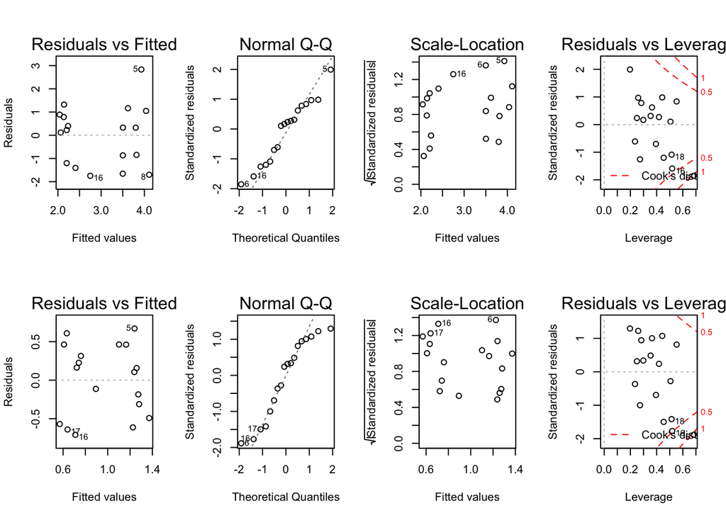

```r
# step 3 - apply log() transformation to linear model to fix bad residuals
mod_full_lin_log <- lm(log(diversity_estimate) ~ compartment_age +
                 canopy_closure + leaf_litter_depth + understory_height +
                 No_WaterBodies + near_Primary, data = SR_data)

# step 4 diagnostics OK now
par(mfrow = c(2,4))
plot(mod_full_lin, add.smooth = FALSE)
plot(mod_full_lin_log, add.smooth = FALSE)
```

Now we can make some inference using `Anova()` from the car package and `etasq()` from heplots package to get effect sizes.

```r
# step 5: Anova - nothing is signficant
Anova(mod_full_lin_log)
```

```
## Anova Table (Type II tests)
##
## Response: log(diversity_estimate)
##                   Sum Sq Df F value Pr(>F)
## compartment_age   0.2986  1  0.8930 0.3649
## canopy_closure    0.0333  1  0.0994 0.7584
## leaf_litter_depth 0.0009  1  0.0028 0.9585
## understory_height 0.0944  1  0.2823 0.6057
## No_WaterBodies    0.0066  1  0.0198 0.8907
## near_Primary      0.9223  1  2.7582 0.1250
## Residuals         3.6782 11
```

```r
# Step 6: Medium effect sizes....
eta <- etasq(mod_full_lin_log, anova = TRUE)
eta
```

```
## Anova Table (Type II tests)
##
## Response: log(diversity_estimate)
##                   Partial eta^2 Sum Sq Df F value Pr(>F)
## compartment_age        0.075090 0.2986  1  0.8930 0.3649
## canopy_closure         0.008959 0.0333  1  0.0994 0.7584
## leaf_litter_depth      0.000258 0.0009  1  0.0028 0.9585
## understory_height      0.025024 0.0944  1  0.2823 0.6057
## No_WaterBodies         0.001794 0.0066  1  0.0198 0.8907
## near_Primary           0.200474 0.9223  1  2.7582 0.1250
## Residuals                       3.6782 11
```

#### Linear Modelling with iNEXT data: Conclusions

1. There are no significant effects of the habitat characteristics on Asymptotic estimates of species richness derived from iNEXT for each compartment.
2. The effect size of being close or not to a primary forest is Large
3. The effect size of Compartment age is Medium and of understory height is small.
4. The other terms have very small effect size

### MVABUND approach

The mvabund approach fits a generalised linear model (GLM) to each species abundances with a common set of predictor variables and specifies the appropriate mean-variance relationship for abundance data (mean increases with variance in count data).

The approach uses resampling to test for significant community level responses to our predictors.

Lets start by visualing the count data for the most abundance species. We need to do some setup of the data. We need a compartment x species matrix as our response variable and then a data frame with the habitat data.

```r
# prepare the abundance data
abund_dat <- comp_age %>%
  ungroup() %>%
  select(starts_with("Sp.")) %>%
  mvabund()

# prepare the habitat data
hab_dat <- SR_data %>%
  select(-Site, -order, -coverage, - diversity_estimate) %>%
  as.data.frame()
```

We can first visualise the abundances of the most abundant species. There are lots of 0’s, as we know.

```
## Kicking off BoxPlot sequence
```

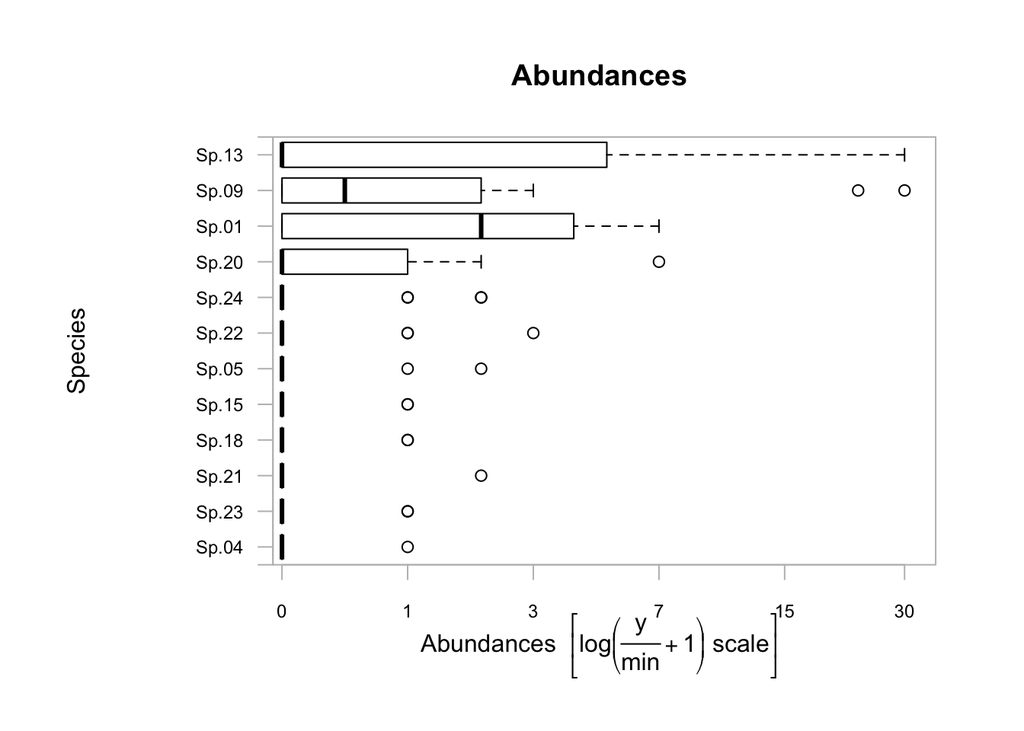

We can fit the multivariate model, assuming poisson or negative binomial distributiuo for the count data. Turns out that with all those 0’s, the negative binomial is best

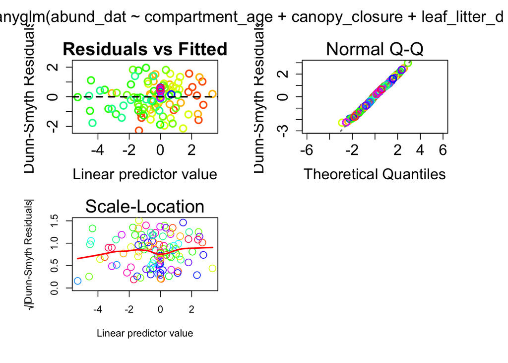

```r
# build the multivariate model of site x species abundance ~ habitat
mv_model <- manyglm(abund_dat ~ compartment_age+
                   canopy_closure +
                   leaf_litter_depth +
                   understory_height +
                   No_WaterBodies +
                   near_Primary,
                 data = hab_dat, family = "negbinomial")

par(mfrow = c(1,3))
plot(mv_model, which = 1:3)
```

Now we can check if we detect any effects of the habitat variables on the species composition of fireflies in the community.

```r
set.seed(2452018)
kable(anova(mv_model)$table)
```

```
## Time elapsed: 0 hr 0 min 42 sec
```

|  | Res.Df | Df.diff | Dev | Pr(>Dev) |
| --- | --- | --- | --- | --- |
| (Intercept) | 17 | NA | NA | NA |
| compartment_age | 16 | 1 | 19.529859 | 0.359 |
| canopy_closure | 15 | 1 | 8.186422 | 0.814 |
| leaf_litter_depth | 14 | 1 | 32.908851 | 0.032 |
| understory_height | 13 | 1 | 23.985601 | 0.101 |
| No_WaterBodies | 12 | 1 | 27.800221 | 0.044 |
| near_Primary | 11 | 1 | 10.117463 | 0.555 |

#### MVabund Conclusions

Our analysis indicate that **leaf litter depth** and **the number of water bodies** influence community composition.